# Operación y Puntualidad de Vuelos Comerciales en Estados Unidos (2024)

¿Cuándo se concentran las demoras y qué tan factible es estimar la probabilidad de retraso antes del despegue?

30 septiembre 2026

## Pregunta de análisis

> **¿Es posible estimar la probabilidad de que un vuelo comercial en Estados Unidos sufra un retraso significativo a partir de la información operativa disponible antes de su salida?**

Según el estándar de la Administración Federal de Aviacón (FAA), consideramos como retraso significativo un vuelo cuya salida ocurrió **15 minutos o más, después de la hora programada**

**HIPÓTESIS**: Las características operativas conocidas previo al despegue; franja horaria programada, mes, día de la semana, aerolínea operadora, aeropuerto de origen/destino y distancia de la ruta, contienen información suficiente para estimar la probabilidad de demora, aunque su capacidad de detección estará sujeta a cambios del mismo día (como la propagación de aeronaves tardías).

## Resumen Ejecutivo

7,079,081 vuelos programados, 20.6% con más de 15 min de retraso, -2.0 min mediana del retraso de salida

Los retrasos aéreos en Estados Unidos durante 2024, (20.6%) de las operaciones efectivas, no ocurren de forma aleatoria. El análisis demuestra tres hallazgos centrales:

1. **El riesgo de retraso se intensifica en verano**, depende de la métrica por aerolinea.
2. **Los retrasos aumentan conforme avanza el día debido al efecto en cadena de vuelos tardíos.**
3. **La distribución geográfica identifica nodos críticos en la red nacional**

## Contexto y criterio de análisis

La fuente de información principal corresponde a los registros públicos del [Bureau of Transportation Statistics (BTS) del Departamento de Transporte de los Estados Unidos (USDOT)](https://transtats.bts.gov/DL_SelectFields.aspx?QO_fu146_anzr=&gnoyr_VQ=FGJ), específicamente el conjunto de datos **Reporting Carrier On-Time Performance**.

Se hizo una extracción directa de los 12 archivos mensuales correspondientes al periodo completo de enero a diciembre de 2024. Teniendo como variables relevantes:

**Variable Objetivo** - `DEP_DEL15`: Indicador binario de retraso en la salida de 15 minutos o más.

**Variables explicativas** - `MONTH`: Mes del año en que opera el vuelo. Del 1 de enero al 12 de diciembre.

- `DAY_OF_WEEK`: Día de la semana del vuelo. Se codifica como 1 = lunes, 2 = martes, …, 7 = domingo.
- `CRS_DEP_TIME`: Hora de salida programada (local) en formato hhmm.
- `OP_UNIQUE_CARRIER`:Código alfanumérico que identifica de forma única a la aerolínea que opera el vuelo (AA, DL, UA).
- `ORIGIN`: Código IATA (tres letras) del aeropuerto donde inicia el vuelo (por ejemplo, JFK, LAX, ORD).
- `DEST`: Código IATA del aeropuerto de llegada.
- `DISTNCE`: Distancia en millas entre el aeropuerto de origen y el de destino.
- `CANCELLED`: Variable binaria que indica si el vuelo fue cancelado.

**Unidad de análisis**: Cada fila representa un vuelo comercial doméstico programado, operado por aerolíneas comerciales certificadas dentro del territorio estadounidense.

**Población y alcance**: Vuelos domésticos en todos los estados de EE. UU. durante el año 2024, **7,079,081** registros totales.

### Decisión de preparación y limipieza de datos.

- Se validó la consistencia estructural de los 12 archivos mensuales antes de consolidar los 7,079,081 registros.
- El 1.4% de los vuelos fueron cancelados `CANCELLED == 1`. Estos registros se excluyeron del cálculo de demoras operativas y del entrenamiento predictivo dado que carecen de tiempo de salida observado.
- Las variables que registran los minutos desglosados por causa `LATE_AIRCRAFT_DELAY`, `WEATHER_DELAY`, `CARRIER_DELAY`, etc. y la demora observada `DEP_DELAY` se utilizan únicamente en el análisis exploratorio para comprender la mecánica del sistema. Fueron excluidas de los predictores del modelo porque solo se conocen una vez que el vuelo ya ocurrió.

> NOTA: Usamos un umbral de retraso de 15 minutos pues mientras que la mediana de retraso en Estados Unidos es de -2.0 minutos (la mayoría de los vuelos salen a tiempo o incluso minutos antes), el promedio asciende a 12.6 minutos, con una desviación estándar de 56.0 minutos (rango intercuartílico de 15.0 min).

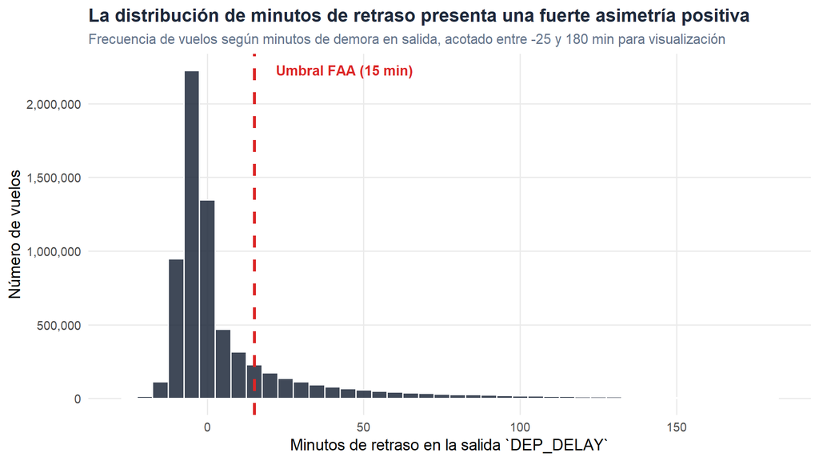

> La marcada cola hacia la derecha explica porque el promedio en minutos es sensible a demoras extremas de varias horas. Por eso usamos el umbral binario de 15 minutos ya que, hace un balance en la métrica de evaluación y evita pequeñas variaciones operativas que no afectan significativamente los tiempos de conexión de los pasajeros.

# 1. El riesgo de retraso se intensifica en verano y depende de la métrica por aerolínea

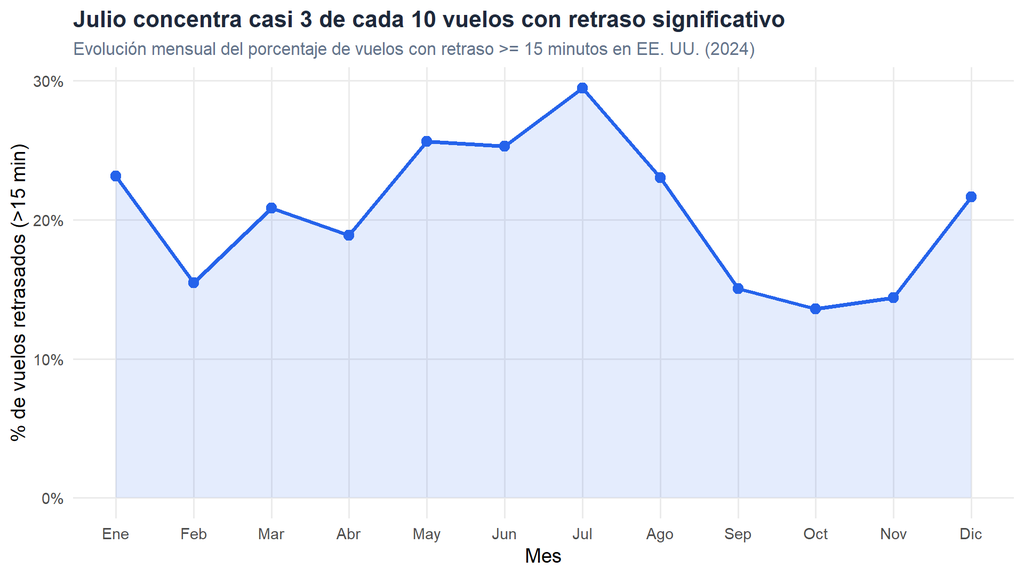

El comportamiento mensual nos confirma que la congestión del sistema aéreo estadounidense no es constante: los meses de verano concentran la mayor proporción de demoras, alcanzando un máximo en julio (29.5%), seguido de un repunte invernal en diciembre.

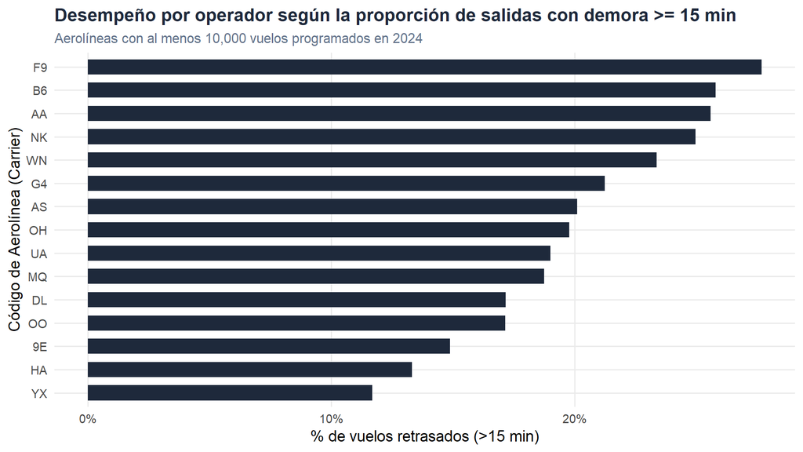

El patrón observado es descriptivo: diferencias en las tasas de retraso por aerolínea están asociadas tanto a su eficiencia operativa como a los aeropuertos (hubs) y horarios en los que concentran sus rutas.

# 2. Los retrasos se multiplican a lo largo del día por el efecto en cadena de aeronaves tardías

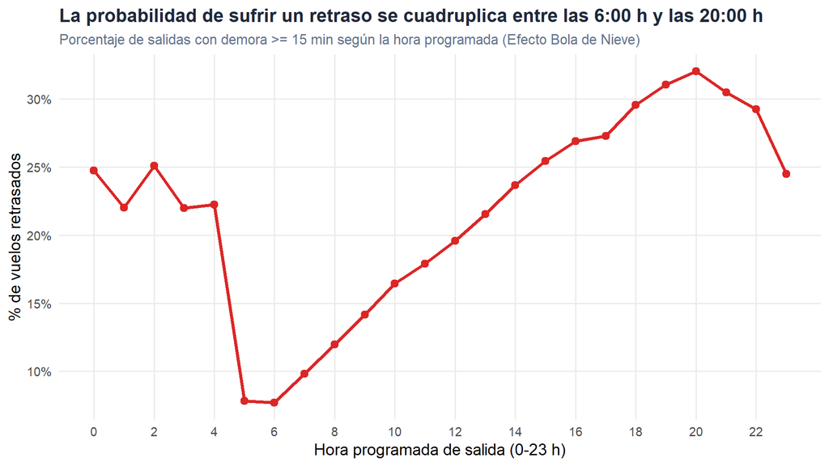

El factor temporal más determinante dentro de una jornada operativa es la hora programada de despegue. Los vuelos que despegan entre las 05:00 y las 07:00 horas presentan tasas de retraso cercanas al **7.7%**, pero la proporción crece de forma continua hasta alcanzar el **32.1% a las 20:00 horas.**

Además, ¿Por qué la puntualidad se deteriora conforme avanza la tarde?

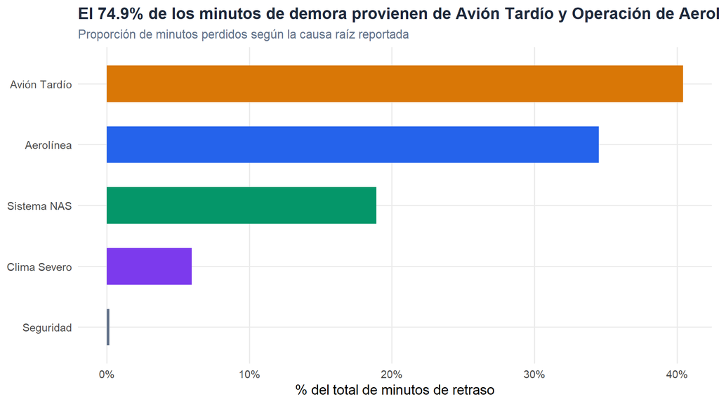

Cuando una aeronave sufre un contratiempo en su primer trayecto matutino, arrastra esa pérdida a todas las rotaciones subsecuentes del día (Avión Tardío). Si bien existe una fuerte asociación entre la hora vespertina y el retraso, el mecanismo subyacente es la propagación acumulada en la red.

# 3. La congestión geográfica identifica nodos críticos en la red nacional.

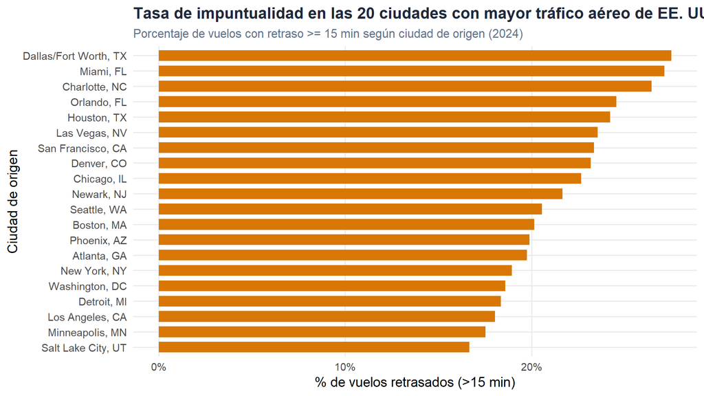

Al ver el alcance a todos los estados del país, observamos que los grandes centros de conexión (hubs), presentan comportamientos heterogéneos: un mayor volumen de vuelos no implica necesariamente la peor tasa de puntualidad, pero sí magnifica el impacto en el sistema nacional cuando ocurren disrupciones.

# 4. Modelado: Estimación de la probabilidad de retraso antes de la salida

Para responder directamente a nuestra pregunta de investigación, formulamos un problema de clasificación supervisada donde buscamos estimar $P(\text{Retraso} \ge 15\text{ min} \mid X_{\text{pre-vuelo}})$. Para ello usaremos un modelo de regresión logística y uno de árbol de decisión para comparar resultados.

### Metodología y diseño experimental

**Comparación de modelos** Para estimar la predicción, usamos dos modelos:

1. Regresión Logística (glm binomial): En nuestro modelo ctúa como línea base (baseline) evaluando efectos aditivos sobre los log-odds de retraso.
2. Random Forest (ranger, 200 árboles): Lo usamos para ver interacciones complejas (por ejemplo, combinaciones específicas de hora, mes y aeropuerto), entrenado con ponderación de clases (class.weights = c(“0” = 1, “1” = 4)) para penalizar los errores sobre la clase minoritaria.

# Principales resultados

**Comparación de modelos y el costo de umbral de decisión** Dado que cerca del 79.4% de los vuelos salen a tiempo, evaluar los clasificadores únicamente con Accuracy en el corte estándar de $p = 0.50$ resulta engañoso. Comparamos primero la capacidad discriminativa global mediante el Área Bajo la Curva ROC (AUC), la cual evalúa el ordenamiento de probabilidades en todos los puntos de corte posibles:

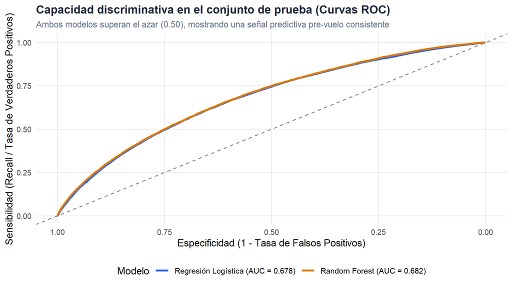

Para abordar el desbalance de clases y analizar el compromiso (trade-off) entre detectar más retrasos reales (Recall) y controlar las falsas alarmas (Precisión), calculamos el umbral óptimo mediante el índice de Youden ($p = 0.202$) y comparamos el desempeño en el conjunto de prueba:

Comparación de modelos y efecto del umbral de decisión sobre el conjunto de prueba (Test Set)

| Modelo y Configuración de Umbral | ROC-AUC | Accuracy | Recall (Sensibilidad) | Especificidad | Precisión | F1-Score |
| --- | --- | --- | --- | --- | --- | --- |
| Regresión Logística (Umbral estándar p = 0.50) | 0.678 | 79.4% | 3.0% | 99.3% | 52.5% | 0.057 |
| Random Forest con pesos (Umbral p = 0.50) | 0.682 | 79.4% | 10.0% | 97.4% | 49.7% | 0.166 |
| Random Forest (Umbral óptimo Youden p = 0.202) | 0.682 | 61.9% | 65.4% | 61.0% | 30.4% | 0.415 |

> Priorizamos el Recall (Sensibilidad) acoplado con el F1-Score y el ROC-AUC, descartando el Accuracy como criterio rector. Con un corte rígido de 0.50, la Regresión Logística obtiene un Accuracy elevado (79.4%) pero un Recall sumamente bajo (3.0%), perdiendo casi todos los retrasos reales. En la gestión aeroportuaria y para el pasajero, un Falso Negativo es mucho más costoso que un Falso Positivo: no anticipar un retraso real implica perder conexiones o desorganizar tripulaciones, mientras que una alerta preventiva (Falso Positivo) solo conlleva tomar margen de precaución. Al utilizar pesos de clase y ajustar el umbral mediante el índice de Youden, logramos capturar el 65.4% de los vuelos demorados reales.

**Matriz de confusión e importancia de las variables**

```
##         Predicho            Real  Freq
## 1       A tiempo A tiempo (<15m) 48424
## 2 Alerta Retraso A tiempo (<15m) 30951
## 3       A tiempo Retraso (>=15m)  7133
## 4 Alerta Retraso Retraso (>=15m) 13493
```

Evaluando la matriz de confusión del Random Forest en su umbral óptimo y la reducción de impureza de Gini de sus predictores, confirmamos qué variables aportan mayor información antes del despegue.

```
## # A tibble: 6 × 2
##   Variable          Importancia
##   <chr>                   <dbl>
## 1 HORA                   27351.
## 2 DIA_SEMANA             14804.
## 3 MONTH                  16157.
## 4 OP_UNIQUE_CARRIER      16396.
## 5 ORIGIN                 25062.
## 6 DEST                   27751.
```

# Conclusiones, limitaciones y posibles extensiones

**Conclusión principal**: Sí es posible estimar la probabilidad de que un vuelo comercial sufra un retraso $\ge 15$ minutos a partir de información conocida antes del despegue, alcanzando un desempeño superior al de un simple hecho aleatrio de ($\text{AUC} \approx 0.68$) y una sensibilidad superior al 65% tdespués de ajustar el umbral de decisión. Vemos que la prooximidad entre el AUC de la Regresión Logística y el del Random Forest demuestra que la señal estática pre-vuelo es consistente pero tiene un techo natural de predicción: **dado que el 74.9% de los minutos de demora dependen de la llegada tardía del avión previo y de la operación del mismo día**, ningún modelo basado exclusivamente en el itinerario programado puede anticipar por completo las disrupciones en tiempo real.